# HW_蔡宜諠711378912

### 【作業2025/04/11】: 2025/04/25 23:59:00 前 繳交

- 使用降維進行分類s
- 比較 PCA, T-SNE 哪一個分類的效果較好(train, test 正確率較高)
- 使用 LogisticRegression
- 資料集 : churn.csv

```python
# -*- coding: utf-8 -*-
from platform import python_version
import os, time, glob
import pandas as pd
import numpy as np

import matplotlib as mpl
import matplotlib.pyplot as plt
import seaborn as sns

import sklearn
from sklearn.decomposition import PCA
from sklearn.manifold import TSNE

print("【日期時間】{}".format(time.strftime("%Y/%m/%d %H:%M:%S")))
print("【工作目錄】{}".format(os.getcwd()))
print("【Python】{}".format(python_version()))
print("【matplotlib】{}".format(mpl.__version__))
print("【seaborn】{}".format(sns.__version__))
print("【sklearn】{}".format(sklearn.__version__))

# %autosave 120
```

```
【日期時間】2025/04/25 17:11:21
【工作目錄】d:\NTPU_class\ml\code
【Python】3.10.5
【matplotlib】3.10.1
【seaborn】0.13.2
【sklearn】1.6.1
```

```python
from matplotlib.font_manager import FontProperties
winfont01 = FontProperties(fname=r"c:\windows\fonts\simsun.ttc", size=12)
winfont02 = FontProperties(fname=r"c:\windows\fonts\kaiu.ttf", size=12)

plt.rcParams['font.sans-serif'] = ['Microsoft JhengHei']  # 設定字型為微軟正黑體
plt.rcParams['axes.unicode_minus'] = False                # 解決負號顯示問題

macfont = FontProperties(fname="/Library/Fonts/Arial Unicode.ttf", size=10)
```

## 查看資料 > 標準化數據 > 切割資料 > PCA / T-SNE > logistic regression

```python
# 載入資料集
churn = pd.read_csv(r'D:\NTPU_class\ml\code\PyMLData\churn.csv', sep=',', encoding='cp950', engine='python')
churn.head(3)
```

|  | state | account_length | area_code | phone_number | international_plan | voice_mail_plan | number_vmail_messages | total_day_minutes | total_day_calls | total_day_charge | ... | total_eve_calls | total_eve_charge | total_night_minutes | total_night_calls | total_night_charge | total_intl_minutes | total_intl_calls | total_intl_charge | number_customer_service_calls | class |
| --- | --- | --- | --- | --- | --- | --- | --- | --- | --- | --- | --- | --- | --- | --- | --- | --- | --- | --- | --- | --- | --- |
| 0 | 16 | 128 | 415 | 2845 | 0 | 1 | 25 | 265.1 | 110 | 45.07 | ... | 99 | 16.78 | 244.7 | 91 | 11.01 | 10.0 | 3 | 2.70 | 1 | 0 |
| 1 | 35 | 107 | 415 | 2301 | 0 | 1 | 26 | 161.6 | 123 | 27.47 | ... | 103 | 16.62 | 254.4 | 103 | 11.45 | 13.7 | 3 | 3.70 | 1 | 0 |
| 2 | 31 | 137 | 415 | 1616 | 0 | 0 | 0 | 243.4 | 114 | 41.38 | ... | 110 | 10.30 | 162.6 | 104 | 7.32 | 12.2 | 5 | 3.29 | 0 | 0 |

3 rows × 21 columns

```python
churn.describe()
```

|  | state | account_length | area_code | phone_number | international_plan | voice_mail_plan | number_vmail_messages | total_day_minutes | total_day_calls | total_day_charge | ... | total_eve_calls | total_eve_charge | total_night_minutes | total_night_calls | total_night_charge | total_intl_minutes | total_intl_calls | total_intl_charge | number_customer_service_calls | class |
| --- | --- | --- | --- | --- | --- | --- | --- | --- | --- | --- | --- | --- | --- | --- | --- | --- | --- | --- | --- | --- | --- |
| count | 5000.00000 | 5000.00000 | 5000.000000 | 5000.000000 | 5000.000000 | 5000.000000 | 5000.000000 | 5000.000000 | 5000.000000 | 5000.000000 | ... | 5000.000000 | 5000.000000 | 5000.000000 | 5000.000000 | 5000.000000 | 5000.000000 | 5000.000000 | 5000.000000 | 5000.000000 | 5000.000000 |
| mean | 25.99840 | 100.25860 | 436.911400 | 2499.500000 | 0.094600 | 0.264600 | 7.755200 | 180.288900 | 100.029400 | 30.649668 | ... | 100.191000 | 17.054322 | 200.391620 | 99.919200 | 9.017732 | 10.261780 | 4.435200 | 2.771196 | 1.570400 | 0.141400 |
| std | 14.80348 | 39.69456 | 42.209182 | 1443.520003 | 0.292691 | 0.441164 | 13.546393 | 53.894699 | 19.831197 | 9.162069 | ... | 19.826496 | 4.296843 | 50.527789 | 19.958686 | 2.273763 | 2.761396 | 2.456788 | 0.745514 | 1.306363 | 0.348469 |
| min | 0.00000 | 1.00000 | 408.000000 | 0.000000 | 0.000000 | 0.000000 | 0.000000 | 0.000000 | 0.000000 | 0.000000 | ... | 0.000000 | 0.000000 | 0.000000 | 0.000000 | 0.000000 | 0.000000 | 0.000000 | 0.000000 | 0.000000 | 0.000000 |
| 25% | 13.00000 | 73.00000 | 408.000000 | 1249.750000 | 0.000000 | 0.000000 | 0.000000 | 143.700000 | 87.000000 | 24.430000 | ... | 87.000000 | 14.140000 | 166.900000 | 87.000000 | 7.510000 | 8.500000 | 3.000000 | 2.300000 | 1.000000 | 0.000000 |
| 50% | 26.00000 | 100.00000 | 415.000000 | 2499.500000 | 0.000000 | 0.000000 | 0.000000 | 180.100000 | 100.000000 | 30.620000 | ... | 100.000000 | 17.090000 | 200.400000 | 100.000000 | 9.020000 | 10.300000 | 4.000000 | 2.780000 | 1.000000 | 0.000000 |
| 75% | 39.00000 | 127.00000 | 415.000000 | 3749.250000 | 0.000000 | 1.000000 | 17.000000 | 216.200000 | 113.000000 | 36.750000 | ... | 114.000000 | 19.900000 | 234.700000 | 113.000000 | 10.560000 | 12.000000 | 6.000000 | 3.240000 | 2.000000 | 0.000000 |
| max | 50.00000 | 243.00000 | 510.000000 | 4999.000000 | 1.000000 | 1.000000 | 52.000000 | 351.500000 | 165.000000 | 59.760000 | ... | 170.000000 | 30.910000 | 395.000000 | 175.000000 | 17.770000 | 20.000000 | 20.000000 | 5.400000 | 9.000000 | 1.000000 |

8 rows × 21 columns

```python
churn.iloc[:, 4:-1].columns  # 前幾個可以不用取得
```

```
Index(['international_plan', 'voice_mail_plan', 'number_vmail_messages',
       'total_day_minutes', 'total_day_calls', 'total_day_charge',
       'total_eve_minutes', 'total_eve_calls', 'total_eve_charge',
       'total_night_minutes', 'total_night_calls', 'total_night_charge',
       'total_intl_minutes', 'total_intl_calls', 'total_intl_charge',
       'number_customer_service_calls'],
      dtype='object')
```

```python
from collections import Counter
# 切一下x, y
X = churn.iloc[:, 4:-1].values
churn['class'] = churn['class'].apply(str)  # 這裡是分類 所以把它變成字串先
y = churn.values[:, -1]
print(X.shape)
print(y.shape)
print(Counter(y))
# 這裡看起來他的y 有些許的資料不平衡 很猶豫要不要處理不平衡 ><
# 所以我決定都做好了 留下原本不平衡的 也做先用不平衡處理的
# 但我先標準化且切割完再處理資料不平衡好了
```

```
(5000, 16)
(5000,)
Counter({'0': 4293, '1': 707})
```

### 標準化

```python
from sklearn.preprocessing import StandardScaler
# 標準化一下
scaler = StandardScaler()
X_std = scaler.fit_transform(X)
```

### 切割資料

```python
from sklearn.model_selection import train_test_split


# 切一下訓練 & 測試集
X_train, X_test, y_train, y_test = train_test_split(X_std, y, test_size=0.2, random_state=42)

shapes = {
    'X': [X_train.shape, X_test.shape],
    'y': [y_train.shape, y_test.shape]
}

# 將數據轉換為 pandas DataFrame
shape_df = pd.DataFrame(shapes, index=['訓練集', '測試集'])
print("【切割後 X y 的 shape】")
print(shape_df)
```

```
【切割後 X y 的 shape】
              X        y
訓練集  (4000, 16)  (4000,)
測試集  (1000, 16)  (1000,)
```

### 處理資料不平衡

```python
from imblearn.over_sampling import SMOTE
smote = SMOTE(sampling_strategy='auto',          # 抽樣的策略
              random_state=None,                 # seed
              k_neighbors=5)                     # k 鄰近幾個點
X_train_smote, y_train_smote = smote.fit_resample(X_train, y_train)

print("---【Original】----------")
print(Counter(y_train))
print("---【Smote】----------")
print(Counter(y_train_smote))
# 有些會沒辦法抽到太遠的地方去
# 這裡欄位太多 不太能可視化
```

```
---【Original】----------
Counter({'0': 3432, '1': 568})
---【Smote】----------
Counter({'0': 3432, '1': 3432})
```

### 降維

#### 依據主成分個數降維 ( 使用原始數據 )

```python
pca = PCA(n_components=2)  # 這裡降到 2 維
X_train_pca_2d = pca.fit_transform(X_train)
# 使用相同的 PCA 模型轉換測試集
X_test_pca_2d = pca.transform(X_test)


# 展示 PCA 結果
print("\n【轉換前後 X shape】")
shapes = {
    '轉換前 X': [X_train.shape, X_test.shape],
    '轉換後 X': [X_train_pca_2d.shape, X_test_pca_2d.shape]
}
shape_df = pd.DataFrame(shapes, index=['訓練集', '測試集'])
print(shape_df)

variance_df = pd.DataFrame({
    '主成分': [f'PC{i+1}' for i in range(len(pca.explained_variance_ratio_))],
    '解釋能力百分比': [f'{var*100:.2f}%' for var in pca.explained_variance_ratio_],
    '累積解釋能力百分比': [f'{var*100:.2f}%' for var in pca.explained_variance_ratio_.cumsum()]
})
print("\n【主成分解釋能力的詳細表格】")
print(variance_df)
```

```
【轉換前後 X shape】
          轉換前 X      轉換後 X
訓練集  (4000, 16)  (4000, 2)
測試集  (1000, 16)  (1000, 2)

【主成分解釋能力的詳細表格】
   主成分 解釋能力百分比 累積解釋能力百分比
0  PC1  13.00%    13.00%
1  PC2  12.85%    25.86%
```

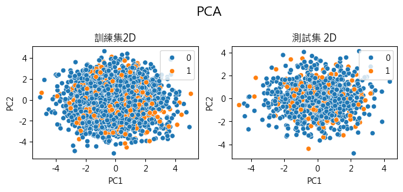

```python
import seaborn as sns
import matplotlib.pyplot as plt
plt.figure(figsize=[8, 3])
plt.subplots_adjust(top=0.75)
plt.suptitle("PCA", fontsize=16)
plt.subplot(1, 2, 1)
sns.scatterplot(x=X_train_pca_2d[:, 0], y=X_train_pca_2d[:, 1], hue=y_train)
# 給他一下標題 圖例
plt.title("訓練集2D")
plt.xlabel("PC1")
plt.ylabel("PC2")
plt.legend(loc='upper right')

plt.subplot(1, 2, 2)
sns.scatterplot(x=X_test_pca_2d[:, 0], y=X_test_pca_2d[:, 1], hue=y_test)
# 給他一下標題 圖例
plt.title("測試集 2D")
plt.xlabel("PC1")
plt.ylabel("PC2")
plt.legend(loc='upper right')

plt.show()
```

可以看到不管事不管是解釋能力或是可視化結果都不是太好 可以想像應該是因為放進去的欄位很多 接下來就用總解釋能力去降維

#### 依據主成分個數降維 ( 使用處理過的不平衡訓練集 )

```python
pca = PCA(n_components=2)  # 這裡降到 2 維
X_smote_train_pca_2d = pca.fit_transform(X_train_smote)
# 使用相同的 PCA 模型轉換測試集
X_smote_test_pca_2d = pca.transform(X_test)


# 展示 PCA 結果
print("\n【轉換前後 X shape】")
shapes = {
    '轉換前 X': [X_train_smote.shape, X_test.shape],
    '轉換後 X': [X_smote_train_pca_2d.shape, X_smote_test_pca_2d.shape]
}
shape_df = pd.DataFrame(shapes, index=['訓練集', '測試集'])
print(shape_df)

variance_df = pd.DataFrame({
    '主成分': [f'PC{i+1}' for i in range(len(pca.explained_variance_ratio_))],
    '解釋能力百分比': [f'{var*100:.2f}%' for var in pca.explained_variance_ratio_],
    '累積解釋能力百分比': [f'{var*100:.2f}%' for var in pca.explained_variance_ratio_.cumsum()]
})
print("\n【主成分解釋能力的詳細表格】")
print(variance_df)
```

```
【轉換前後 X shape】
          轉換前 X      轉換後 X
訓練集  (6864, 16)  (6864, 2)
測試集  (1000, 16)  (1000, 2)

【主成分解釋能力的詳細表格】
   主成分 解釋能力百分比 累積解釋能力百分比
0  PC1  17.15%    17.15%
1  PC2  12.92%    30.07%
```

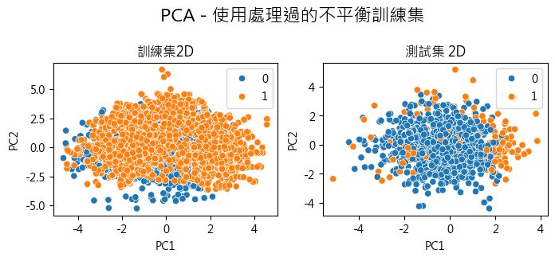

```python
import seaborn as sns
import matplotlib.pyplot as plt
plt.figure(figsize=[8, 3])
plt.subplots_adjust(top=0.75)
plt.suptitle("PCA - 使用處理過的不平衡訓練集", fontsize=16)
plt.subplot(1, 2, 1)
sns.scatterplot(x=X_smote_train_pca_2d[:, 0], y=X_smote_train_pca_2d[:, 1], hue=y_train_smote)
# 給他一下標題 圖例
plt.title("訓練集2D")
plt.xlabel("PC1")
plt.ylabel("PC2")
plt.legend(loc='upper right')

plt.subplot(1, 2, 2)
sns.scatterplot(x=X_smote_test_pca_2d[:, 0], y=X_smote_test_pca_2d[:, 1], hue=y_test)
# 給他一下標題 圖例
plt.title("測試集 2D")
plt.xlabel("PC1")
plt.ylabel("PC2")
plt.legend(loc='upper right')


plt.show()
```

從這裡看起來 處理過不平衡後的訓練集結果顯示有比較好一點

#### 依據主成分總解釋能力降維 ( 使用原始數據 )

```python
pca_95 = PCA(n_components=0.95)
X_train_pca_95 = pca_95.fit_transform(X_train)
# 使用相同的 PCA 模型轉換測試集
X_test_pca_95 = pca_95.transform(X_test)

# 展示 PCA 結果
print("\n【轉換前後 X shape】")
shapes = {
    '轉換前 X': [X_train.shape, X_test.shape],
    '轉換後 X': [X_train_pca_95.shape, X_test_pca_95.shape]
}
shape_df = pd.DataFrame(shapes, index=['訓練集', '測試集'])
print(shape_df)

variance_df = pd.DataFrame({
    '主成分': [f'PC{i+1}' for i in range(len(pca_95.explained_variance_ratio_))],
    '解釋能力百分比': [f'{var*100:.2f}%' for var in pca_95.explained_variance_ratio_],
    '累積解釋能力百分比': [f'{var*100:.2f}%' for var in pca_95.explained_variance_ratio_.cumsum()]
})
print("\n【主成分解釋能力的詳細表格】")
print(variance_df)
```

```
【轉換前後 X shape】
          轉換前 X       轉換後 X
訓練集  (4000, 16)  (4000, 11)
測試集  (1000, 16)  (1000, 11)

【主成分解釋能力的詳細表格】
     主成分 解釋能力百分比 累積解釋能力百分比
0    PC1  13.00%    13.00%
1    PC2  12.85%    25.86%
2    PC3  12.40%    38.26%
3    PC4  12.26%    50.52%
4    PC5  12.15%    62.67%
5    PC6   6.44%    69.11%
6    PC7   6.35%    75.46%
7    PC8   6.16%    81.63%
8    PC9   6.12%    87.75%
9   PC10   6.06%    93.80%
10  PC11   5.92%    99.72%
```

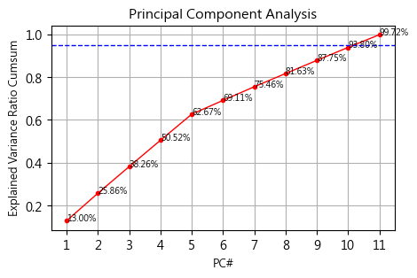

```python
plt.figure(figsize=[5, 3])

plt.plot(range(1, len(pca_95.explained_variance_ratio_.cumsum())+1), pca_95.explained_variance_ratio_.cumsum(),
         linestyle="-", linewidth=1, color="red", marker=".")
plt.grid(True)
plt.xlabel("PC#", fontsize=9)
plt.ylabel("Explained Variance Ratio Cumsum", fontsize=9)
plt.title("Principal Component Analysis", fontsize=11)
plt.xticks(range(1, len(pca_95.explained_variance_ratio_.cumsum())+1))

for x_, y_ in zip(range(1, len(pca_95.explained_variance_ratio_.cumsum())+1), pca_95.explained_variance_ratio_.cumsum()) :
    plt.text(x_, y_, f"{y_:.2%}", fontsize=7)


# 繪製選擇 PC 的總解釋百分比門檻值
plt.axhline(y=0.95, xmin=0, xmax=1, linestyle="--", linewidth=1, color="blue") # 以解釋率要到達多少去畫線
plt.show()
```

#### 依據主成分總解釋能力降維 ( 使用處理過的不平衡訓練集 )

```python
pca_95_smote = PCA(n_components=0.95)
X_smote_train_pca_95 = pca_95_smote.fit_transform(X_train_smote)
# 使用相同的 PCA 模型轉換測試集
X_smote_test_pca_95 = pca_95_smote.transform(X_test)

# 展示 PCA 結果
print("\n【轉換前後 X shape】")
shapes = {
    '轉換前 X': [X_train_smote.shape, X_test.shape],
    '轉換後 X': [X_smote_train_pca_95.shape, X_smote_test_pca_95.shape]
}
shape_df = pd.DataFrame(shapes, index=['訓練集', '測試集'])
print(shape_df)

variance_df = pd.DataFrame({
    '主成分': [f'PC{i+1}' for i in range(len(pca_95_smote.explained_variance_ratio_))],
    '解釋能力百分比': [f'{var*100:.2f}%' for var in pca_95_smote.explained_variance_ratio_],
    '累積解釋能力百分比': [f'{var*100:.2f}%' for var in pca_95_smote.explained_variance_ratio_.cumsum()]
})
print("\n【主成分解釋能力的詳細表格】")
print(variance_df)
```

```
【轉換前後 X shape】
          轉換前 X       轉換後 X
訓練集  (6864, 16)  (6864, 11)
測試集  (1000, 16)  (1000, 11)

【主成分解釋能力的詳細表格】
     主成分 解釋能力百分比 累積解釋能力百分比
0    PC1  17.15%    17.15%
1    PC2  12.92%    30.07%
2    PC3  11.04%    41.11%
3    PC4  10.50%    51.61%
4    PC5  10.34%    61.95%
5    PC6   9.20%    71.15%
6    PC7   7.37%    78.52%
7    PC8   5.55%    84.07%
8    PC9   5.45%    89.52%
9   PC10   5.22%    94.75%
10  PC11   5.06%    99.80%
```

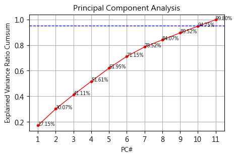

```python
plt.figure(figsize=[5, 3])

plt.plot(range(1, len(pca_95_smote.explained_variance_ratio_.cumsum())+1), pca_95_smote.explained_variance_ratio_.cumsum(),
         linestyle="-", linewidth=1, color="red", marker=".")
plt.grid(True)
plt.xlabel("PC#", fontsize=9)
plt.ylabel("Explained Variance Ratio Cumsum", fontsize=9)
plt.title("Principal Component Analysis", fontsize=11)
plt.xticks(range(1, len(pca_95_smote.explained_variance_ratio_.cumsum())+1))

for x_, y_ in zip(range(1, len(pca_95_smote.explained_variance_ratio_.cumsum())+1), pca_95_smote.explained_variance_ratio_.cumsum()) :
    plt.text(x_, y_, f"{y_:.2%}", fontsize=7)


# 繪製選擇 PC 的總解釋百分比門檻值
plt.axhline(y=0.95, xmin=0, xmax=1, linestyle="--", linewidth=1, color="blue") # 以解釋率要到達多少去畫線
plt.show()
```

這裡沒有因為處理了資料不平衡 就少一點主成分 影響比較小

#### 降維2維 ( 使用原始數據 )

```python
from sklearn.manifold import TSNE
import numpy as np
import seaborn as sns
import matplotlib.pyplot as plt
import warnings
warnings.filterwarnings('ignore', category=FutureWarning)

tsne = TSNE(
    n_components=2,    # 降維幾維
    n_iter=1000,       # 跌代次數
)
# t-SNE 沒有 transform 所以這裡只能先合併資料 後面再用index取得
X_all = np.concatenate([X_train, X_test], axis=0)
y_all = np.concatenate([y_train, y_test], axis=0)
X_all_tsne = tsne.fit_transform(X_all)

X_train_tsne_2d = X_all_tsne[:len(X_train), :]  # 訓練集的降維結果
X_test_tsne_2d = X_all_tsne[len(X_train):, :]  # 測試集的降維結果

print("\n【tsne 轉換前後 X shape】")
shapes = {
    '轉換前 X': [X_train.shape, X_test.shape],
    '轉換後 X': [X_train_tsne_2d.shape, X_test_tsne_2d.shape]
}
shape_df = pd.DataFrame(shapes, index=['訓練集', '測試集'])
print(shape_df)
```

```
【tsne 轉換前後 X shape】
          轉換前 X      轉換後 X
訓練集  (4000, 16)  (4000, 2)
測試集  (1000, 16)  (1000, 2)
```

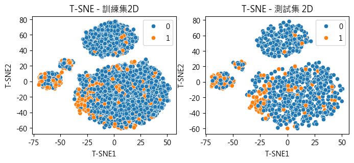

```python
plt.figure(figsize=[8, 3])
plt.subplot(1, 2, 1)
sns.scatterplot(x=X_train_tsne_2d[:, 0], y=X_train_tsne_2d[:, 1], hue=y_train)
# 給他一下標題 圖例
plt.title("T-SNE - 訓練集2D")
plt.xlabel("T-SNE1")
plt.ylabel("T-SNE2")
plt.legend(loc='upper right')

plt.subplot(1, 2, 2)
sns.scatterplot(x=X_test_tsne_2d[:, 0], y=X_test_tsne_2d[:, 1], hue=y_test)
# 給他一下標題 圖例
plt.title("T-SNE - 測試集 2D")
plt.xlabel("T-SNE1")
plt.ylabel("T-SNE2")
plt.legend(loc='upper right')

plt.show()
```

這裡可以看到分得很不好 所以我考慮把降維維度從 2 維增加到 3 維  
(T-SNE 在 method 為 barnes_hut 下 最多降到三維，exact 太追求精準 數據很少的時候才適合選擇 這裡不考慮 )

#### 降維2維( 使用處理過的不平衡訓練集 )

```python
warnings.filterwarnings('ignore', category=FutureWarning)

tsne = TSNE(
    n_components=2,    # 降維幾維
    n_iter=1000,       # 跌代次數
)
# t-SNE 沒有 transform 所以這裡只能先合併資料 後面再用index取得
X_all = np.concatenate([X_train_smote, X_test], axis=0)
y_all = np.concatenate([y_train_smote, y_test], axis=0)
X_all_tsne = tsne.fit_transform(X_all)

X_smote_train_tsne_2d = X_all_tsne[:len(X_train_smote), :]  # 訓練集的降維結果
X_smote_test_tsne_2d = X_all_tsne[len(X_train_smote):, :]  # 測試集的降維結果

print("\n【tsne 轉換前後 X shape】")
shapes = {
    '轉換前 X': [X_train_smote.shape, X_test.shape],
    '轉換後 X': [X_smote_train_tsne_2d.shape, X_smote_test_tsne_2d.shape]
}
shape_df = pd.DataFrame(shapes, index=['訓練集', '測試集'])
print(shape_df)
```

```
【tsne 轉換前後 X shape】
          轉換前 X      轉換後 X
訓練集  (6864, 16)  (6864, 2)
測試集  (1000, 16)  (1000, 2)
```

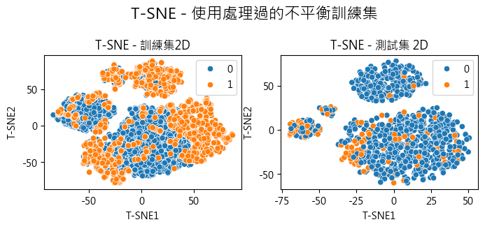

```python
plt.figure(figsize=[8, 3])
plt.subplots_adjust(top=0.75)
plt.suptitle("T-SNE - 使用處理過的不平衡訓練集", fontsize=16)
plt.subplot(1, 2, 1)
sns.scatterplot(x=X_smote_train_tsne_2d[:, 0], y=X_smote_train_tsne_2d[:, 1], hue=y_train_smote)
# 給他一下標題 圖例
plt.title("T-SNE - 訓練集2D")
plt.xlabel("T-SNE1")
plt.ylabel("T-SNE2")
plt.legend(loc='upper right')

plt.subplot(1, 2, 2)
sns.scatterplot(x=X_test_tsne_2d[:, 0], y=X_test_tsne_2d[:, 1], hue=y_test)
# 給他一下標題 圖例
plt.title("T-SNE - 測試集 2D")
plt.xlabel("T-SNE1")
plt.ylabel("T-SNE2")
plt.legend(loc='upper right')

plt.show()
```

光是肉眼看還是沒有比較好的感覺!

#### 降維3維 ( 使用原始數據 )

```python
warnings.filterwarnings('ignore', category=FutureWarning)

tsne = TSNE(
    n_components=3,    # 降維幾維
    n_iter=1000,       # 跌代次數
)
# t-SNE 沒有 transform 所以這裡只能先合併資料 後面再用index取得
X_all = np.concatenate([X_train, X_test], axis=0)
y_all = np.concatenate([y_train, y_test], axis=0)
X_all_tsne = tsne.fit_transform(X_all)

X_train_tsne_3d = X_all_tsne[:len(X_train), :]  # 訓練集的降維結果
X_test_tsne_3d = X_all_tsne[len(X_train):, :]  # 測試集的降維結果

print("\n【tsne 轉換前後 X shape】")
shapes = {
    '轉換前 X': [X_train.shape, X_test.shape],
    '轉換後 X': [X_train_tsne_3d.shape, X_test_tsne_3d.shape]
}
shape_df = pd.DataFrame(shapes, index=['訓練集', '測試集'])
print(shape_df)
```

```
【tsne 轉換前後 X shape】
          轉換前 X      轉換後 X
訓練集  (4000, 16)  (4000, 3)
測試集  (1000, 16)  (1000, 3)
```

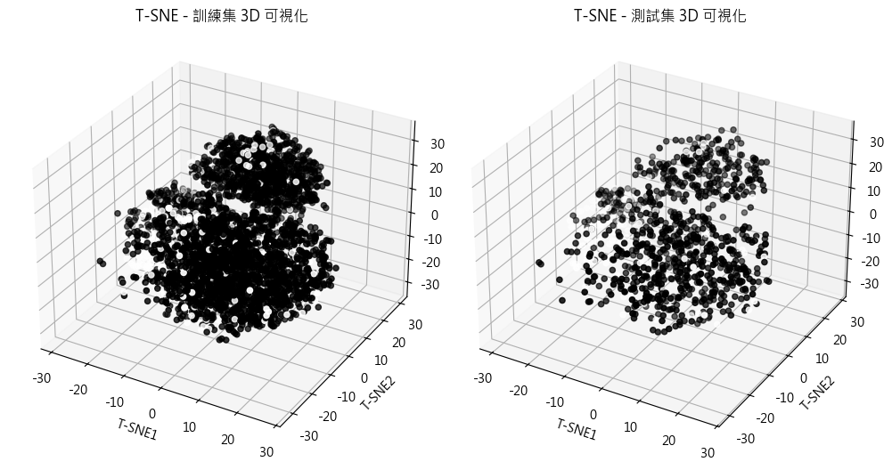

```python
from mpl_toolkits.mplot3d import Axes3D

fig = plt.figure(figsize=(10, 8))

# 訓練集的 3D 散點圖
ax = fig.add_subplot(121, projection='3d')
ax.scatter(X_train_tsne_3d[:, 0], X_train_tsne_3d[:, 1], X_train_tsne_3d[:, 2], c=y_train)
ax.set_title("T-SNE - 訓練集 3D 可視化")
ax.set_xlabel('T-SNE1')
ax.set_ylabel('T-SNE2')
ax.set_zlabel('T-SNE3')

# 測試集的 3D 散點圖
ax = fig.add_subplot(122, projection='3d')
ax.scatter(X_test_tsne_3d[:, 0], X_test_tsne_3d[:, 1], X_test_tsne_3d[:, 2], c=y_test)
ax.set_title("T-SNE - 測試集 3D 可視化")
ax.set_xlabel('T-SNE1')
ax.set_ylabel('T-SNE2')
ax.set_zlabel('T-SNE3')

plt.tight_layout()
plt.show()
```

看起來還是分得很不好呢!

#### 降維3維( 使用處理過的不平衡訓練集 )

```python
warnings.filterwarnings('ignore', category=FutureWarning)

tsne = TSNE(
    n_components=3,    # 降維幾維
    n_iter=1000,       # 跌代次數
)
# t-SNE 沒有 transform 所以這裡只能先合併資料 後面再用index取得
X_all = np.concatenate([X_train_smote, X_test], axis=0)
y_all = np.concatenate([y_train_smote, y_test], axis=0)
X_all_tsne = tsne.fit_transform(X_all)

X_smote_train_tsne_3d = X_all_tsne[:len(X_train_smote), :]  # 訓練集的降維結果
X_smote_test_tsne_3d = X_all_tsne[len(X_train_smote):, :]  # 測試集的降維結果

print("\n【tsne 轉換前後 X shape】")
shapes = {
    '轉換前 X': [X_train_smote.shape, X_test.shape],
    '轉換後 X': [X_smote_train_tsne_3d.shape, X_smote_test_tsne_3d.shape]
}
shape_df = pd.DataFrame(shapes, index=['訓練集', '測試集'])
print(shape_df)
```

```
【tsne 轉換前後 X shape】
          轉換前 X      轉換後 X
訓練集  (6864, 16)  (6864, 3)
測試集  (1000, 16)  (1000, 3)
```

不畫3D圖了 3D圖好難看出甚麼東西

### logistic regression

```python
# 將資料集放入列表中
X_train_list = [
    X_train, X_train_smote,
    X_train_pca_2d, X_smote_train_pca_2d, X_train_pca_95, X_smote_train_pca_95,
    X_train_tsne_2d, X_smote_train_tsne_2d, X_train_tsne_3d, X_smote_train_tsne_3d
    ]
X_test_list = [
    X_test, X_test,
    X_test_pca_2d, X_smote_test_pca_2d, X_test_pca_95, X_smote_test_pca_95,
    X_test_tsne_2d, X_smote_test_tsne_2d, X_test_tsne_3d, X_smote_test_tsne_3d
    ]
y_train_list = [
    y_train, y_train_smote,
    y_train, y_train_smote, y_train, y_train_smote,
    y_train, y_train_smote, y_train, y_train_smote
    ]
y_test_list = [
    y_test, y_test,
    y_test, y_test, y_test, y_test,
    y_test, y_test, y_test, y_test
    ]  # y_test 是一致的
names_list = [
    "original", "original smote",
    "PCA 2D", "PCA 2D smote", "PCA 95% 11D", "PCA 95% 11D smote",
    "t-SNE 2D","t-SNE 2D smote", "t-SNE 3D", "t-SNE 3D smote"]
```

```python
from sklearn.linear_model import LogisticRegression
from sklearn.metrics import accuracy_score

def train_and_evaluate(X_train_list, X_test_list, y_train_list, y_test_list, names_list):
    accuracies = []
    for X_train, X_test, y_train, y_test, name in zip(X_train_list, X_test_list, y_train_list, y_test_list, names_list):
        # 訓練邏輯回歸模型
        model = LogisticRegression(max_iter=1000)
        model.fit(X_train, y_train)
        y_pred = model.predict(X_test)
        accuracy = accuracy_score(y_test, y_pred)
        accuracies.append(accuracy)
        model.fit(X_train, y_train)
        print(f'【 {name} 】')
        print(f"train acc : {model.score(X_train, y_train):.2%}")
        print(f"test acc : {model.score(X_test, y_test):.2%}")
        print("===========================")
    return accuracies

accuracies = train_and_evaluate(X_train_list, X_test_list, y_train_list, y_test_list, names_list)
```

```
【 original 】
train acc : 86.38%
test acc : 86.70%
===========================
【 original smote 】
train acc : 78.38%
test acc : 77.10%
===========================
【 PCA 2D 】
train acc : 85.80%
test acc : 86.10%
===========================
【 PCA 2D smote 】
train acc : 61.45%
test acc : 62.20%
===========================
【 PCA 95% 11D 】
train acc : 86.40%
test acc : 87.00%
===========================
【 PCA 95% 11D smote 】
train acc : 78.12%
test acc : 76.70%
===========================
【 t-SNE 2D 】
train acc : 86.12%
test acc : 86.40%
===========================
【 t-SNE 2D smote 】
train acc : 68.81%
test acc : 70.30%
===========================
【 t-SNE 3D 】
train acc : 86.00%
test acc : 86.10%
===========================
【 t-SNE 3D smote 】
train acc : 65.41%
test acc : 65.10%
===========================
```

### 📈Summary

1. 從這裡可以看出來 前面雖然主成分經過資料不平衡處理後，主成分累積解釋能力百分比些許提升，但後續進入模型後表現不佳，因此這裡**後續不會再對他做資料不平衡的處理**。
2. 就整體而言【 PCA 95% 11D 】模型表現最好，選擇保留較多主成分有助於提高模型，甚至還比原先的模型高出一些些。
3. 【 t-SNE 2D 】僅僅保留了兩個維度，雖然表現不如【 PCA 95% 11D 】，但2D可以有效降低計算複雜度，如果資料更需要可視化和查看不同類別的分布時，可以選擇這個模型。